# Reuter et al. 2025 Analysis Version 2

## Fitting decay curve to F(S4247*)

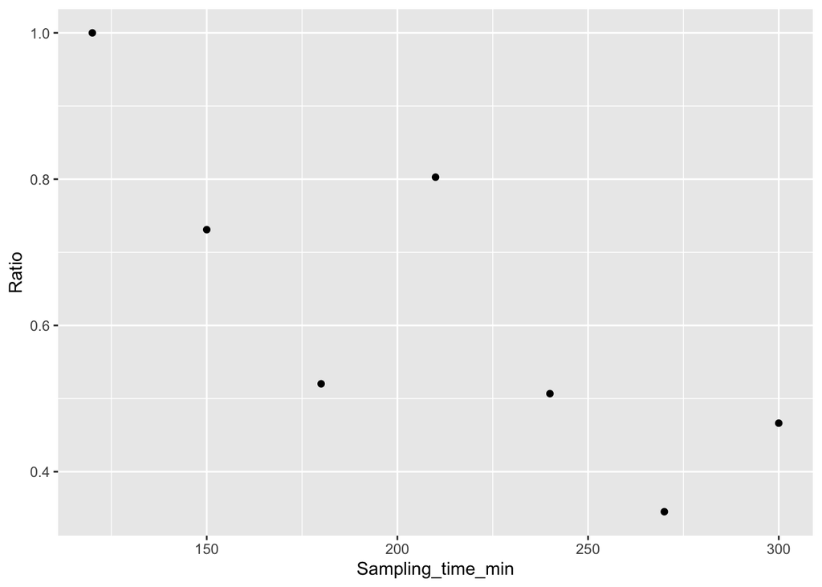

```r
# Visualize decay using a dotplot
ggplot(data1[data1$Genotype=="S427*",], aes(Sampling_time_min,Ratio))+
  geom_point()
```

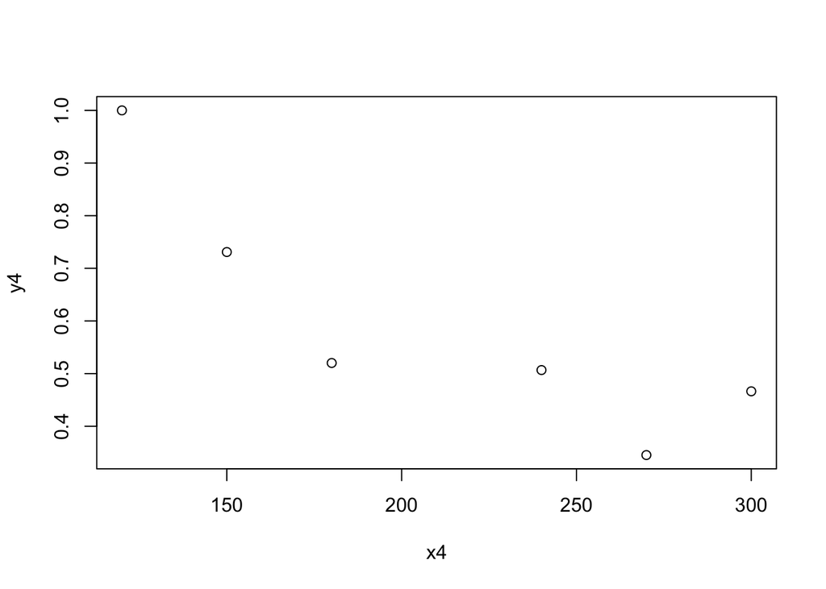

```r
# remove outlier t210
x4=data1[data1$Genotype=="S427*"&data1$Sampling_time_min!="210",]$Sampling_time_min
y4=data1[data1$Genotype=="S427*"& data1$Sampling_time_min!="210",]$Ratio

plot(x4,y4)
```

```r
# Model selection between linear and exponential decay model
## Linear model
d1=lm(y4~x4)

## Exponential decay model: Select appropriate starting values; Select an approximate $\theta$, since theta must be lower than min(y), and greater than zero
theta.0 <- min(y4) * 0.5

### Estimate the rest parameters using a linear model
model.0 <- lm(log(y4 - theta.0) ~ x4)
alpha.0 <- exp(coef(model.0)[1])
beta.0 <- coef(model.0)[2]

### Starting parameters
start <- list(alpha = alpha.0, beta = beta.0)
d2 <- nls(y4 ~ alpha * exp(beta * x4) ,  start = start)

### Model comparison to chose the best fit model using AIC and BIC
AIC(d1,d2)
```

```
##    df       AIC
## d1  3 -3.548757
## d2  3 -5.901902
```

```r
#  df       AIC
#d1  3 -3.548757
#d2  3 -5.901902

BIC(d1,d2)
```

```
##    df       BIC
## d1  3 -4.173478
## d2  3 -6.526623
```

```r
# df       BIC
# d1  3 -4.173478
# d2  3 -6.526623

# ==> Model d2 selected based on the lower AIC and BIC

## Extract parameter estimates
summary(d2)
```

```
##
## Formula: y4 ~ alpha * exp(beta * x4)
##
## Parameters:
##        Estimate Std. Error t value Pr(>|t|)
## alpha  1.745038   0.407150   4.286   0.0128 *
## beta  -0.005442   0.001313  -4.146   0.0143 *
## ---
## Signif. codes:  0 '***' 0.001 '**' 0.01 '*' 0.05 '.' 0.1 ' ' 1
##
## Residual standard error: 0.1099 on 4 degrees of freedom
##
## Number of iterations to convergence: 6
## Achieved convergence tolerance: 2.651e-06
```

```r
## alpha: 1.75, beta: -0.0054

# Model validation for d2
## Create an evironment to save validation plots at high resolution
#output_file <- "decay_S427_fitting.jpeg"
#jpeg(filename = output_file, width = 8, height = 4, units = "in", res = 600)

## Plot layout Fig S14D
par(mfrow=c(1,2))

## qqplot
qqPlot(residuals(d2))
```

```
## [1] 3 6
```

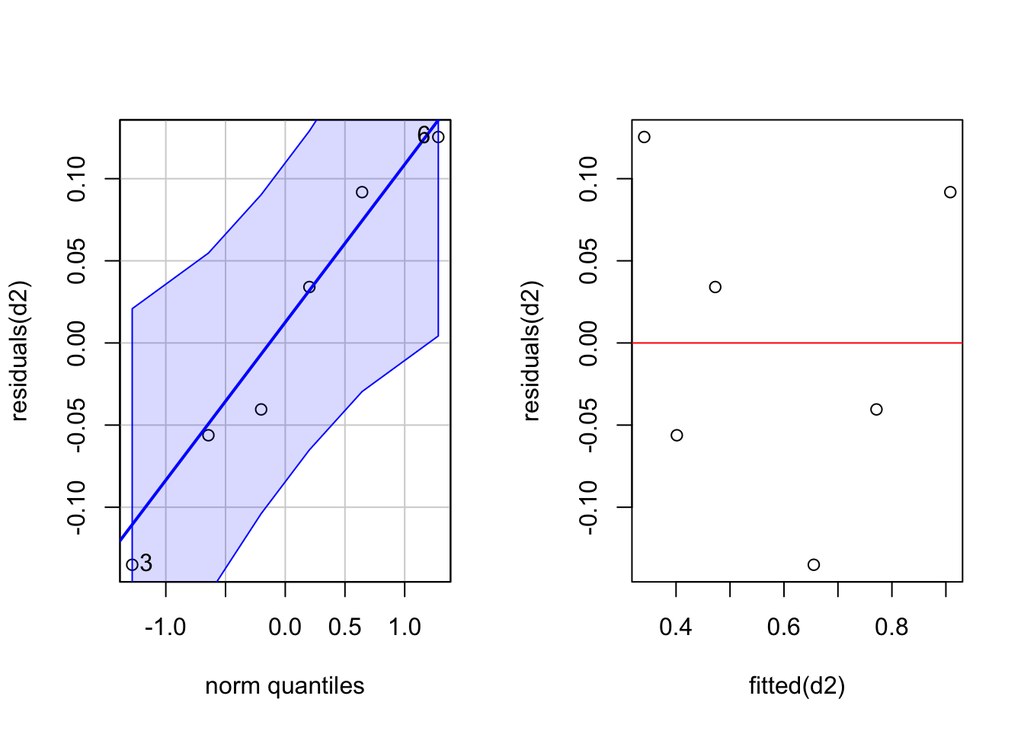

```r
## residuals vs fitted values plot
plot(residuals(d2)~fitted(d2))
abline(a=0, b=0, col="red")
```

```r
#dev.off()
```

## **Visualize decay measured and predicted values for all genotypes in one plot**

(Figure Fig. 5B)

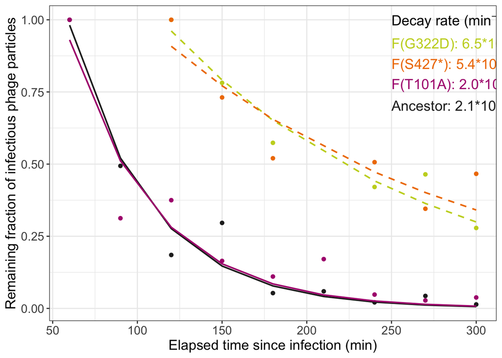

```r
# Visualize decay data using dot and line plots
a=ggplot()+
  geom_point(aes(x=x1,y=y1),color="#252525")+ # measured decay ancestor
    geom_point(aes(x=x2,y=y2),color="#ae017e")+ # measured decay F(T101A)
  geom_point(aes(x=x3,y=y3),color="#c6d325")+ # measured decay F(G322D)
  geom_point(aes(x=x4,y=y4),color="#ef7c00")+ # measured decay F(S427*)
annotate(geom="text", x=250, y=1.00, hjust=0, label=expression("Decay rate (min"^{-1}*"):"),
         color="black", fontface="bold", size=5)+ # Decay rate text
  annotate(geom="text", x=250, y=0.92, hjust=0,label=expression("F(G322D): 6.5*10"^{-3}*""),
         color="#c6d325", fontface="bold", size=5)+ # Decay rate text F(G322D)
  annotate(geom="text", x=250, y=0.85, hjust=0,label=expression("F(S427*): 5.4*10"^{-3}*""),
         color="#ef7c00", fontface="bold", size=5)+# Decay rate text F(S427*)
  annotate(geom="text", x=250, y=0.78, hjust=0,label=expression("F(T101A): 2.0*10"^{-2}*""),
         color="#ae017e", fontface="bold", size=5)+# Decay rate text F(T101A)
  annotate(geom="text", x=250, y=0.71, hjust=0,label=expression("Ancestor: 2.1*10"^{-2}*""),
         color="#252525", fontface="bold", size=5)+ # Decay rate text ancestor
  geom_line(aes(x=x1, y=predict(a2)),color="#252525", size=0.75)+ # predicted decay ancestor
    geom_line(aes(x=x2, y=predict(b2)),color="#ae017e", size=0.75)+ # predicted decay F(T101A)
  geom_line(aes(x=x3, y=predict(c2)),color="#c6d325", linetype="dashed",size=0.75)+ # predicted decay F(G322D)
  geom_line(aes(x=x4, y=predict(d2)),color="#ef7c00", linetype="dashed",size=0.75)+ # predicted decay F(S427*)
  xlab("Elapsed time since infection (min)")+ # label x-axis
  ylab("Remaining fraction of infectious phage particles")+ # label y-axis
  theme_bw()+ # plot layout
  theme(axis.text=element_text(size=12),
        axis.title=element_text(size=14)) # font size
a
```

```r
# Save plot at high resolution
# ggsave("decay_plot.jpeg", plot = a, dpi = 600, width = 9, height = 7)
```

# Experiment 7: One-step growth curve of ancestral phage

Code used to generate Fig. S6 in the manuscript

**READ ME** *Specification of columns in data set*

- **Genotype**: Phage genotype for which OSGC was done: wild type (WT)
- **MOI**: Multiplicity of infectiousness input when adsorption is initiated
- **Sampling_time_min**: Sampling time point in minutes after the 6-minute synchronised adsorption period, followed by a 2000x dilution step
- **PFU_1**: Plaque-forming unit counts (PFU) for the first plating of triplicate plating for phage lysate for each sampling time point
- **PFU_2**: Plaque-forming unit counts (PFU) for the second plating of triplicate plating for phage lysate for each sampling time point
- **PFU_3**: Plaque-forming unit counts (PFU) for the third plating of triplicate plating for phage lysate for each sampling time point
- **Median_PFU**: Median PFU counts from triplicate plating PFU_1, PFU_2, PFU_3. If triplicate plating was not possible, the mean of two platings or just one plating value was taken for phage titer calculation. The reason for this was not enough sampling volume to do triplicate plating (i.e. at early time points).
- **Dilution_PFU**: Plating dilution used to plate phage lysate isolated after the one-step growth curve using chloroform in a plaque assay
- **Dilution_OSGC**: Dilution step between adsorption and OSGC sampling to prevent secondary infection. The dilution step for all three one-step runs was a 2000-fold dilution using 10 µl of bacteria-phage mix after adsorption and diluting it into 20 ml supplemented, prewarmed (37 °C) LB medium.
- **PFU_ml**: Phage concentration in plaque-forming units per ml (PFU/ml), calculated from Median_PFU *Dilution_PFU
- **t0_PFU_ml**: Phage concentration in PFU/ml at time point t0 after adsorption. These are free phages which need to be subtracted from each following time point phage titer to normalise the data for free/unadsorbed phages.
- **PFU_t0_norm**: Normalised PFU concentration for each time point calculated by PFU_ml - t0_PFU_ml
- **Bacteria_CFU_ml**: Bacteria concentration in colony-forming units per ml CFU/ml) at the start of the adsorption period. Calculated by counting colony-forming units (CFU)* Plating dilution (10^6)
- **Infected_CFU_ml**: Number of Bacteria which could be in theory infected by phages, calculated by Bacteria_CFU_ml*MOI/Dilution_OSGC
- **PFU_ml_produced**: Mean phage burst size at each sampling time point
- **Elapsed_time**: Elapsed time since adsorption. Calculated by adding 6 min adsorption to each “Sampling_time_ min” OSGC sampling time point

## Load data set

```r
df=read.csv("experiment_7_OSGC_WT.csv")

# df has 11 observations and 16 variables
```

## Checking data set

```r
str(df) # structure of  columns
```

```
## 'data.frame':    11 obs. of  16 variables:
##  $ Genotype         : chr  "WT" "WT" "WT" "WT" ...
##  $ MOI              : num  0.1 0.1 0.1 0.1 0.1 0.1 0.1 0.1 0.1 0.1 ...
##  $ Sampling_time_min: int  1 2 3 4 5 6 8 10 15 20 ...
##  $ PFU_1            : num  17 26 6 12 134 ...
##  $ PFU_2            : int  11 18 NA 11 148 119 23 33 15 16 ...
##  $ PFU_3            : int  NA NA NA NA 136 129 14 65 18 21 ...
##  $ Median_PFU       : num  14 22 6 11.5 136 129 23 65 18 21 ...
##  $ Dilution_PFU     : num  2.5 2.5 3.3 5.0 1.0e+01 1.0e+02 1.0e+04 1.0e+04 1.0e+05 1.0e+05 ...
##  $ Dilution_OSGC    : int  2000 2000 2000 2000 2000 2000 2000 2000 2000 2000 ...
##  $ PFU_ml           : num  3.50e+01 5.50e+01 1.98e+01 5.75e+01 1.36e+03 1.29e+04 2.30e+05 6.50e+05 1.80e+06 2.10e+06 ...
##  $ t0_PFU_ml        : num  35 35 35 35 35 35 35 35 35 35 ...
##  $ PFU_t0_norm      : num  0 20 -15.2 22.5 1330 12900 230000 650000 1800000 2100000 ...
##  $ Bacteria_CFU_ml  : num  2.81e+08 2.81e+08 2.81e+08 2.81e+08 2.81e+08 2.81e+08 2.81e+08 2.81e+08 2.81e+08 2.81e+08 ...
##  $ Infected_CFU_ml  : num  14100 14100 14100 14100 14100 14100 14100 14100 14100 14100 ...
##  $ PFU_ml_produced  : num  0 0 0 0 0.09 ...
##  $ Elapsed_time     : int  7 8 9 10 11 12 14 16 21 26 ...
```

## Visualize phage concentration for each time point

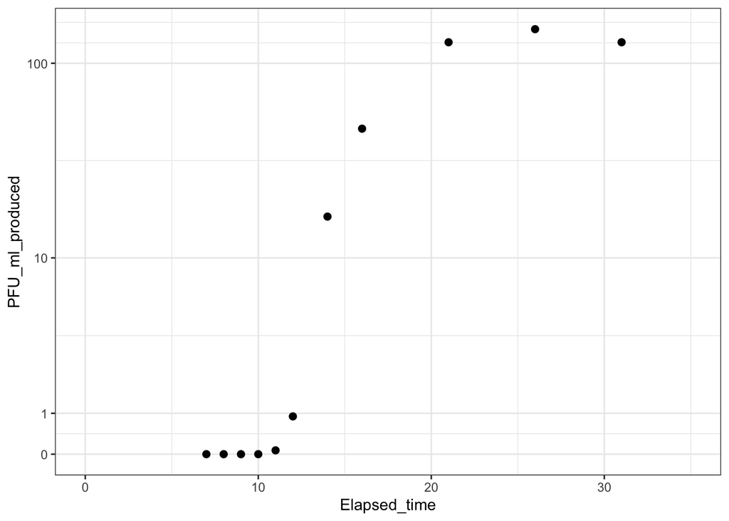

```r
ggplot(df, aes(Elapsed_time,PFU_ml_produced))+
  geom_point(size=2)+ # dot plot
     scale_y_continuous(trans = scales::pseudo_log_trans(),
                     breaks = c(0, 10^(0:6)))+ # log transformed y axis
  xlim(0,35)+ # set x limits so time point 0-6 min (adsorption time) are also visualized
  theme_bw() # plot layout
```